# Tugas Praktikum 1 MPDW

Yehezki Novandri Liman

2025-09-01

# Memanggil Library

```r
library(readxl)
```

```r
library(ggplot2)
library(forecast)
library(graphics)
library(TTR)
library(TSA)
library(rio)
```

# Memanggil Data

```r
data <- read_xlsx("C:\\Users\\Yehezki\\Downloads\\Page Loads.xlsx")
print(data)
```

```
## # A tibble: 2,167 × 2
##    Date                Page.Loads
##    <dttm>                   <dbl>
##  1 2014-09-14 00:00:00       2146
##  2 2014-09-15 00:00:00       3621
##  3 2014-09-16 00:00:00       3698
##  4 2014-09-17 00:00:00       3667
##  5 2014-09-18 00:00:00       3316
##  6 2014-09-19 00:00:00       2815
##  7 2014-09-20 00:00:00       1658
##  8 2014-09-21 00:00:00       2288
##  9 2014-09-22 00:00:00       3638
## 10 2014-09-23 00:00:00       4462
## # ℹ 2,157 more rows
```

## Mengambil Data pada Baris ke-101 Sampai 200

```r
df <- data[101:200,]
print(df)
```

```
## # A tibble: 100 × 2
##    Date                Page.Loads
##    <dttm>                   <dbl>
##  1 2014-12-23 00:00:00       2298
##  2 2014-12-24 00:00:00       1430
##  3 2014-12-25 00:00:00       1002
##  4 2014-12-26 00:00:00       1486
##  5 2014-12-27 00:00:00       1345
##  6 2014-12-28 00:00:00       1453
##  7 2014-12-29 00:00:00       2173
##  8 2014-12-30 00:00:00       2208
##  9 2014-12-31 00:00:00       1381
## 10 2015-01-01 00:00:00       1265
## # ℹ 90 more rows
```

# Eksplorasi Data

str() = menampilkan struktur data, sedangkan dim() = menampilkan dimensi data.

```r
str(df)
```

```
## tibble [100 × 2] (S3: tbl_df/tbl/data.frame)
##  $ Date      : POSIXct[1:100], format: "2014-12-23" "2014-12-24" ...
##  $ Page.Loads: num [1:100] 2298 1430 1002 1486 1345 ...
```

```r
dim(df)
```

```
## [1] 100   2
```

## Melakukan Pengecekan Missing Value

```r
colSums(is.na(df))
```

```
##       Date Page.Loads
##          0          0
```

Data tidak memiliki missing value.

## Melakukan Pengecekan Duplicated Data

```r
duplicated(df)
```

```
##   [1] FALSE FALSE FALSE FALSE FALSE FALSE FALSE FALSE FALSE FALSE FALSE FALSE
##  [13] FALSE FALSE FALSE FALSE FALSE FALSE FALSE FALSE FALSE FALSE FALSE FALSE
##  [25] FALSE FALSE FALSE FALSE FALSE FALSE FALSE FALSE FALSE FALSE FALSE FALSE
##  [37] FALSE FALSE FALSE FALSE FALSE FALSE FALSE FALSE FALSE FALSE FALSE FALSE
##  [49] FALSE FALSE FALSE FALSE FALSE FALSE FALSE FALSE FALSE FALSE FALSE FALSE
##  [61] FALSE FALSE FALSE FALSE FALSE FALSE FALSE FALSE FALSE FALSE FALSE FALSE
##  [73] FALSE FALSE FALSE FALSE FALSE FALSE FALSE FALSE FALSE FALSE FALSE FALSE
##  [85] FALSE FALSE FALSE FALSE FALSE FALSE FALSE FALSE FALSE FALSE FALSE FALSE
##  [97] FALSE FALSE FALSE FALSE
```

Tidak ada data yang terduplikasi. Data siap digunakan.

```r
summary(df$Page.Loads)
```

```
##    Min. 1st Qu.  Median    Mean 3rd Qu.    Max.
##    1002    2768    3850    3790    5030    5884
```

Menampilkan ringkasan dari data.

## Mengubah Tipe Data Agar Terbaca Sebagai Data Deret Waktu

```r
df.ts <- ts(df$Page.Loads)
```

## Membuat Plot Time Series

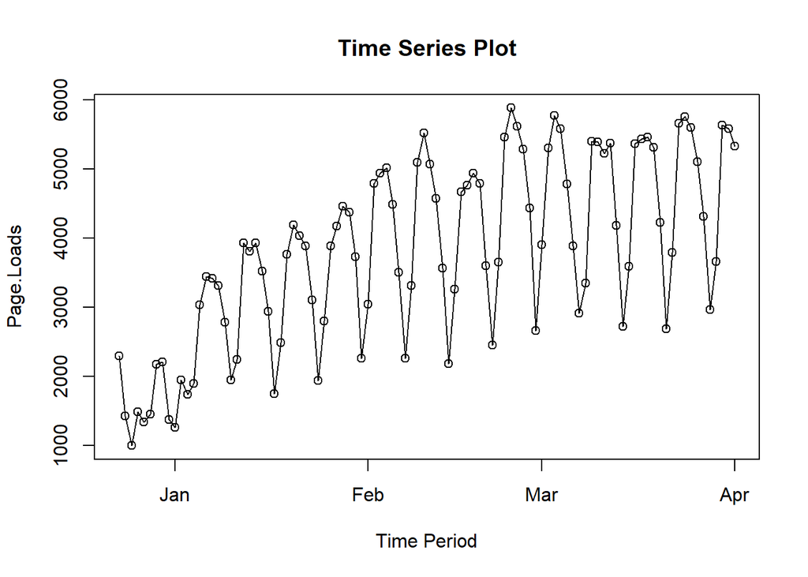

```r
plot(df$Date, df$Page.Loads, type = "l",
     xlab="Time Period", ylab="Page.Loads",
     main = "Time Series Plot")
points(df)
```

# Proses Pemulusan Moving Average

## Pembagian Data

Pembagian data latih dan data uji dilakukan dengan perbandingan 80% data latih dan 20% data uji.

```r
n <- nrow(df)

# Menentukan batas data train yang akan dimasukkan
n_train <- floor(0.8 * n)

# Melakukan Pembagian
training <- df[1:n_train, ]
testing  <- df[(n_train+1):n, ]

# Mengubah Tipe ke Time Series
train.ts <- ts(training$Page.Loads)
test.ts  <- ts(testing$Page.Loads)
```

## Eksplorasi Data Hasil Pembagian

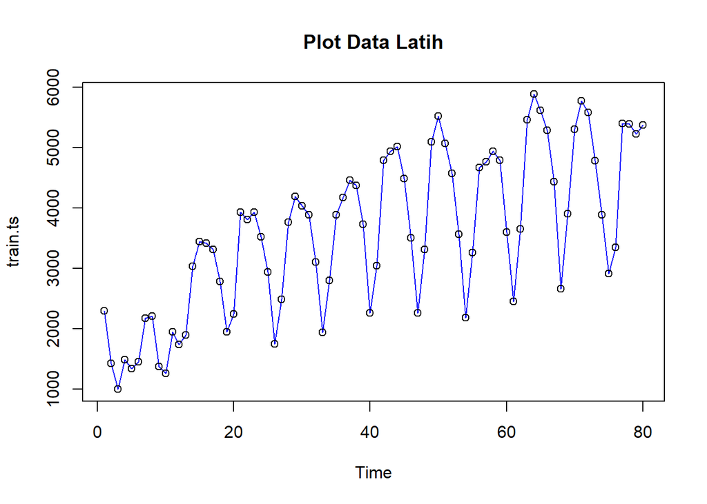

```r
# Eksplorasi Data Latih
plot(train.ts, col="blue",main="Plot Data Latih")
points(train.ts)
```

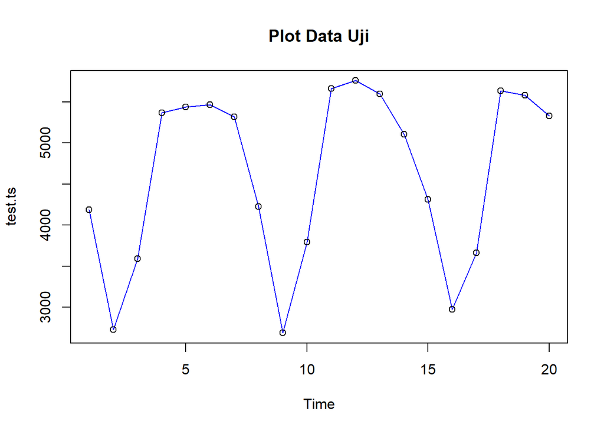

```r
# Eksplorasi Data Uji
plot(test.ts, col="blue",main="Plot Data Uji")
points(test.ts)
```

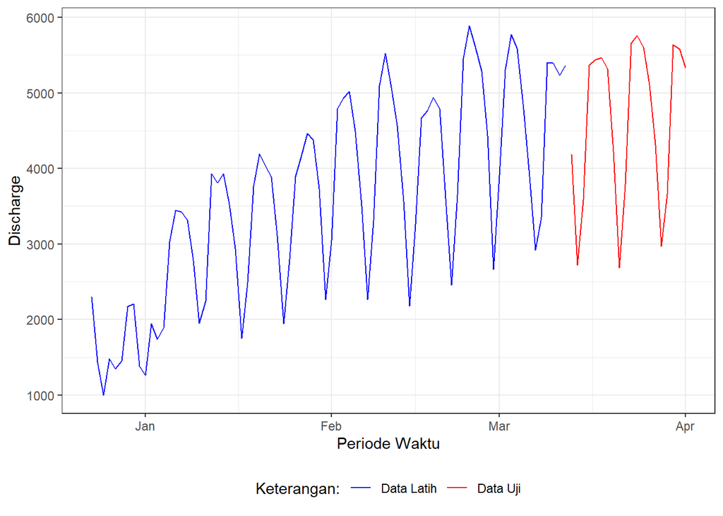

```r
# Eksplorasi Keseluruhan Data
ggplot() +
  geom_line(data = training, aes(x = Date, y = Page.Loads, col = "Data Latih")) +
  geom_line(data = testing, aes(x = Date, y = Page.Loads, col = "Data Uji")) +
  labs(x = "Periode Waktu", y = "Discharge", color = "Legend") +
   scale_colour_manual(name="Keterangan:", breaks = c("Data Latih", "Data Uji"),
                      values = c("blue", "red")) +
  theme_bw() + theme(legend.position = "bottom",
                     plot.caption = element_text(hjust=0.5, size=12))
```

## Single Moving Average

Pemulusan dilakukan dengan metode Single Moving Average dengan parameter m = 4.

```r
df.sma<-SMA(train.ts, n=4)
df.sma
```

```
## Time Series:
## Start = 1
## End = 80
## Frequency = 1
##  [1]      NA      NA      NA 1554.00 1315.75 1321.50 1614.25 1794.75 1803.75
## [10] 1756.75 1700.50 1584.00 1712.75 2154.75 2529.00 2949.25 3305.00 3242.50
## [19] 2869.25 2574.75 2727.00 2983.75 3478.50 3798.00 3551.75 3037.00 2677.00
## [28] 2737.75 3050.50 3622.25 3972.25 3808.50 3246.50 2937.50 2937.75 3203.00
## [37] 3832.50 4226.25 4186.75 3709.25 3355.75 3460.00 3760.50 4449.00 4808.75
## [46] 4486.50 3818.50 3393.00 3544.50 4049.50 4752.00 5066.25 4685.00 3849.25
## [55] 3397.00 3421.75 3720.25 4410.50 4791.75 4525.25 3948.00 3624.75 3793.00
## [64] 4363.00 5153.00 5562.75 5305.50 4500.75 4073.75 4078.50 4413.25 5143.25
## [73] 5362.25 5008.50 4294.50 3736.50 3890.75 4266.25 4844.25 5348.75
```

Data pemulusan pada periode ke-t selanjutnya digunakan sebagai nilai peramalan pada periode ke t+1 sehingga hasil peramalan 1 periode kedepan adalah sebagai berikut.

```r
data.ramal<-c(NA,df.sma)
data.ramal
```

```
##  [1]      NA      NA      NA      NA 1554.00 1315.75 1321.50 1614.25 1794.75
## [10] 1803.75 1756.75 1700.50 1584.00 1712.75 2154.75 2529.00 2949.25 3305.00
## [19] 3242.50 2869.25 2574.75 2727.00 2983.75 3478.50 3798.00 3551.75 3037.00
## [28] 2677.00 2737.75 3050.50 3622.25 3972.25 3808.50 3246.50 2937.50 2937.75
## [37] 3203.00 3832.50 4226.25 4186.75 3709.25 3355.75 3460.00 3760.50 4449.00
## [46] 4808.75 4486.50 3818.50 3393.00 3544.50 4049.50 4752.00 5066.25 4685.00
## [55] 3849.25 3397.00 3421.75 3720.25 4410.50 4791.75 4525.25 3948.00 3624.75
## [64] 3793.00 4363.00 5153.00 5562.75 5305.50 4500.75 4073.75 4078.50 4413.25
## [73] 5143.25 5362.25 5008.50 4294.50 3736.50 3890.75 4266.25 4844.25 5348.75
```

Selanjutnya dilakukan peramalan sebanyak 20 periode sesuai dengan jumlah data uji. Pada metode SMA, seluruh hasil peramalan untuk 20 periode ke depan akan memiliki nilai yang sama dengan hasil ramalan satu periode ke depan.

```r
data.gab<-cbind(
  aktual=c(df.ts),
  pemulusan=c(df.sma,rep(NA,20)),
  ramalan=c(data.ramal,rep(data.ramal[length(data.ramal)],19)))

data.gab
```

```
##        aktual pemulusan ramalan
##   [1,]   2298        NA      NA
##   [2,]   1430        NA      NA
##   [3,]   1002        NA      NA
##   [4,]   1486   1554.00      NA
##   [5,]   1345   1315.75 1554.00
##   [6,]   1453   1321.50 1315.75
##   [7,]   2173   1614.25 1321.50
##   [8,]   2208   1794.75 1614.25
##   [9,]   1381   1803.75 1794.75
##  [10,]   1265   1756.75 1803.75
##  [11,]   1948   1700.50 1756.75
##  [12,]   1742   1584.00 1700.50
##  [13,]   1896   1712.75 1584.00
##  [14,]   3033   2154.75 1712.75
```

[output cut: 86 more lines]

Hasil Pemulusan menggunakan Single Moving Average sebagai berikut:

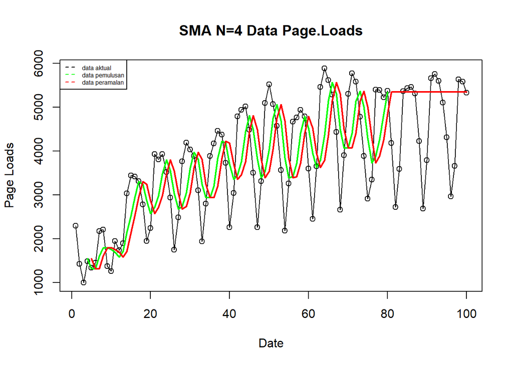

```r
ts.plot(df.ts, xlab="Date", ylab="Page Loads", main= "SMA N=4 Data Page.Loads")
points(df.ts)
lines(data.gab[,2],col="green",lwd=2)
lines(data.gab[,3],col="red",lwd=2)
legend("topleft",c("data aktual","data pemulusan","data peramalan"), lty=8, col=c("black","green","red"), cex=0.5)
```

### Evaluasi dan Akurasi Data Latih dan Data Uji

```r
#Menghitung Keakuratan Data Latih
error_train.sma = train.ts-data.ramal[1:length(train.ts)]

SSE_train.sma = sum(error_train.sma[5:length(train.ts)]^2)
MSE_train.sma = mean(error_train.sma[5:length(train.ts)]^2)
MAPE_train.sma = mean(abs((error_train.sma[5:length(train.ts)]/train.ts[5:length(train.ts)])*100))

akurasi_train.sma <- matrix(c(SSE_train.sma, MSE_train.sma, MAPE_train.sma))
row.names(akurasi_train.sma)<- c("SSE", "MSE", "MAPE")
colnames(akurasi_train.sma) <- c("Akurasi m = 4")
akurasi_train.sma
```

```
##      Akurasi m = 4
## SSE   1.118485e+08
## MSE   1.471691e+06
## MAPE  3.120238e+01
```

Perhitungan akurasi pada data latih menggunakan nilai MAPE menghasilkan nilai MAPE 31.20%. Hal ini menandakan bahwa nilai prediksi yang dihasilkan masih belum terlalu baik.

```r
#Menghitung Keakuratan Data Uji
error_test.sma = test.ts-data.gab[81:100,3]

SSE_test.sma = sum(error_test.sma^2)
MSE_test.sma = mean(error_test.sma^2)
MAPE_test.sma = mean(abs((error_test.sma/test.ts*100)))

akurasi_test.sma <- matrix(c(SSE_test.sma, MSE_test.sma, MAPE_test.sma))
row.names(akurasi_test.sma)<- c("SSE", "MSE", "MAPE")
colnames(akurasi_test.sma) <- c("Akurasi m = 4")
akurasi_test.sma
```

```
##      Akurasi m = 4
## SSE   3.223095e+07
## MSE   1.611548e+06
## MAPE  2.631350e+01
```

Perhitungan akurasi menggunakan data uji menghasilkan nilai MAPE sebesar 26.31% sehingga nilai akurasi ini belum dapat dikategorikan cukup baik. Terlihat bahwa metode pemulusan SMA masih belum efektif.

## Double Moving Average

Pertama-tama, lakukan Single Moving Average (SMA) terlebih dahulu. Lakukan pemulusan dengan parameter m = 4.

Kemudian, lakukan lagi Single Moving Average pada data yang sebelumnya telah dilakukan Single Moving Average. Sehingga data mengalami dua kali Single Moving Average (Double Moving Average).

```r
dma <- SMA(df.sma, n = 4)
At <- 2*df.sma - dma
Bt <- 2/(4-1)*(df.sma - dma)
data.dma<- At+Bt
data.ramal2<- c(NA, data.dma)

t = 1:20
f = c()

for (i in t) {
  f[i] = At[length(At)] + Bt[length(Bt)]*(i)
}

data.gab2 <- cbind(aktual = c(df.ts),
                   pemulusan1 = c(df.sma,rep(NA,20)),
                   pemulusan2 = c(dma, rep(NA,20)),
                   At = c(At, rep(NA,20)),
                   Bt = c(Bt,rep(NA,20)),
                   ramalan = c(data.ramal2, f[-1]))
data.gab2
```

```
##        aktual pemulusan1 pemulusan2       At          Bt   ramalan
##   [1,]   2298         NA         NA       NA          NA        NA
##   [2,]   1430         NA         NA       NA          NA        NA
##   [3,]   1002         NA         NA       NA          NA        NA
##   [4,]   1486    1554.00         NA       NA          NA        NA
##   [5,]   1345    1315.75         NA       NA          NA        NA
##   [6,]   1453    1321.50         NA       NA          NA        NA
##   [7,]   2173    1614.25   1451.375 1777.125  108.583333        NA
##   [8,]   2208    1794.75   1511.562 2077.938  188.791667  1885.708
##   [9,]   1381    1803.75   1633.562 1973.938  113.458333  2266.729
##  [10,]   1265    1756.75   1742.375 1771.125    9.583333  2087.396
##  [11,]   1948    1700.50   1763.938 1637.062  -42.291667  1780.708
##  [12,]   1742    1584.00   1711.250 1456.750  -84.833333  1594.771
##  [13,]   1896    1712.75   1688.500 1737.000   16.166667  1371.917
##  [14,]   3033    2154.75   1788.000 2521.500  244.500000  1753.167
```

[output cut: 86 more lines]

Hasil Pemulusan menggunakan Double Moving Average sebagai berikut:

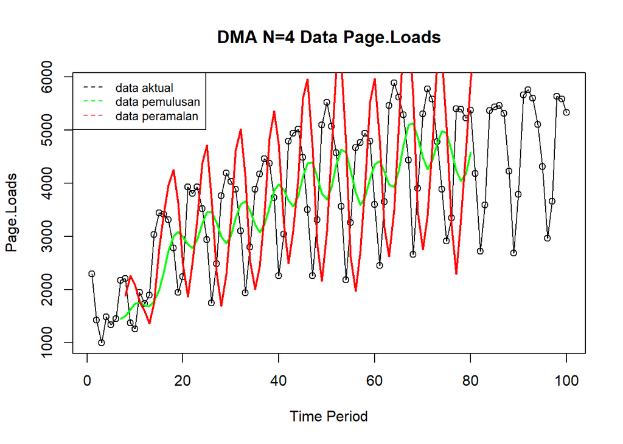

```r
ts.plot(df.ts, xlab="Time Period", ylab="Page.Loads", main= "DMA N=4 Data Page.Loads")
points(df.ts)
lines(data.gab2[,3],col="green",lwd=2)
lines(data.gab2[,6],col="red",lwd=2)
legend("topleft",c("data aktual","data pemulusan","data peramalan"), lty=8, col=c("black","green","red"), cex=0.8)
```

### Evaluasi dan Akurasi Data Latih dan Data Uji

Perhitungan Akurasi dilakukan dengan ukuran akurasi SSE, MSE, dan MAPE.

```r
#Menghitung Keakuratan Data Latih
error_train.dma = train.ts-data.ramal2[1:length(train.ts)]

SSE_train.dma = sum(error_train.dma[8:length(train.ts)]^2)
MSE_train.dma = mean(error_train.dma[8:length(train.ts)]^2)
MAPE_train.dma = mean(abs((error_train.dma[8:length(train.ts)]/train.ts[8:length(train.ts)])*100))

akurasi_train.dma <- matrix(c(SSE_train.dma, MSE_train.dma, MAPE_train.dma))
row.names(akurasi_train.dma)<- c("SSE", "MSE", "MAPE")
colnames(akurasi_train.dma) <- c("Akurasi m = 4")
akurasi_train.dma
```

```
##      Akurasi m = 4
## SSE   2.082645e+08
## MSE   2.852938e+06
## MAPE  4.139245e+01
```

Perhitungan akurasi pada data latih menggunakan nilai MAPE menghasilkan nilai MAPE 41.39%. Hal ini menandakan bahwa nilai prediksi yang dihasilkan masih belum terlalu baik.

```r
#Menghitung Keakuratan Data Uji
error_test.dma = test.ts-data.gab2[81:100,6]
SSE_test.dma = sum(error_test.dma^2)
MSE_test.dma = mean(error_test.dma^2)
MAPE_test.dma = mean(abs((error_test.dma/test.ts*100)))

akurasi_test.dma <- matrix(c(SSE_test.dma, MSE_test.dma, MAPE_test.dma))
row.names(akurasi_test.dma)<- c("SSE", "MSE", "MAPE")
colnames(akurasi_test.dma) <- c("Akurasi m = 4")
akurasi_test.dma
```

```
##      Akurasi m = 4
## SSE   1.093428e+09
## MSE   5.467140e+07
## MAPE  1.593533e+02
```

Perhitungan akurasi menggunakan data uji menghasilkan nilai MAPE sebesar 159.3% sehingga nilai akurasi ini sangat tidak baik dan menunjukkan bahwa pemulusan DMA tidak efektif.

# Pemulusan Eksponensial

## Single Exponential Smoothing (SES)

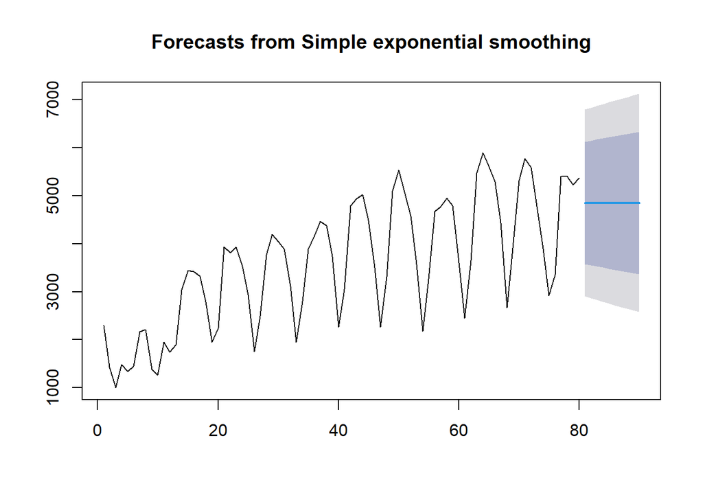

```r
ses.1 <- ses(train.ts, h = 10, alpha = 0.2)
plot(ses.1)
```

```r
ses.1
```

```
##    Point Forecast    Lo 80    Hi 80    Lo 95    Hi 95
## 81       4846.351 3575.342 6117.361 2902.510 6790.193
## 82       4846.351 3550.171 6142.532 2864.014 6828.689
## 83       4846.351 3525.480 6167.223 2826.252 6866.451
## 84       4846.351 3501.241 6191.462 2789.183 6903.520
## 85       4846.351 3477.432 6215.271 2752.770 6939.933
## 86       4846.351 3454.030 6238.673 2716.980 6975.723
## 87       4846.351 3431.015 6261.688 2681.781 7010.922
## 88       4846.351 3408.368 6284.335 2647.146 7045.557
## 89       4846.351 3386.073 6306.630 2613.048 7079.655
## 90       4846.351 3364.112 6328.591 2579.462 7113.241
```

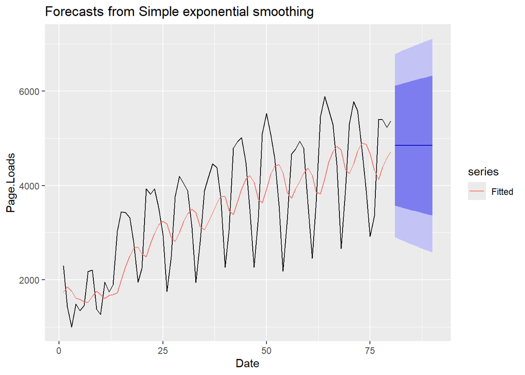

```r
autoplot(ses.1) +
  autolayer(fitted(ses.1), series="Fitted") +
  ylab("Page.Loads") + xlab("Date")
```

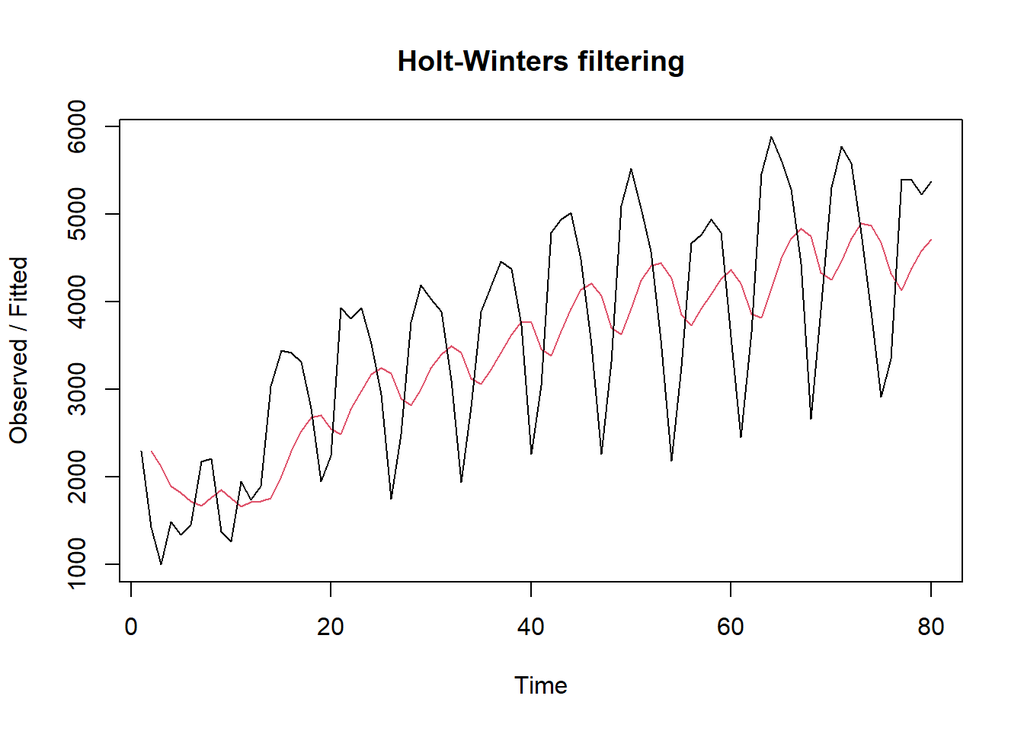

```r
ses1<- HoltWinters(train.ts, gamma = FALSE, beta = FALSE, alpha = 0.2)
plot(ses1)
```

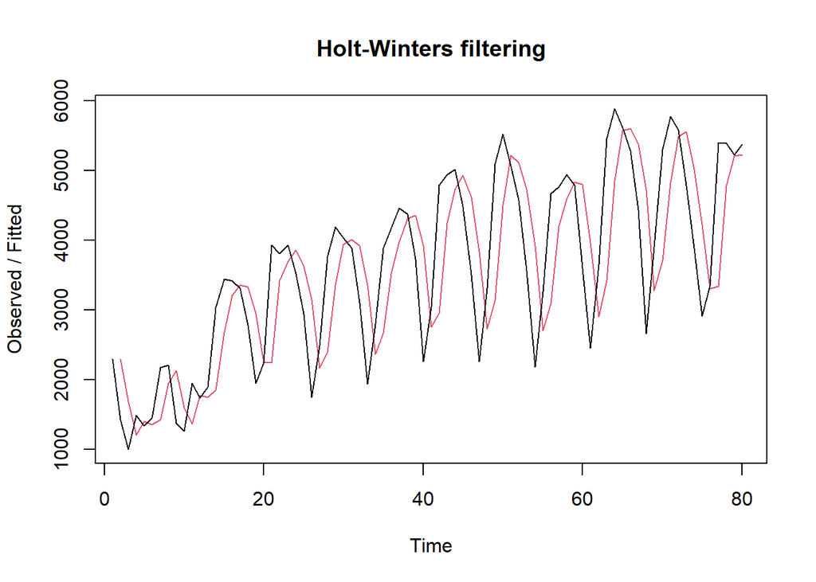

```r
ses2<- HoltWinters(train.ts, gamma = FALSE, beta = FALSE, alpha = 0.7)
plot(ses2)
```

### Peramalan

```r
ramalan1<- forecast(ses1, h=10)
ramalan1
```

```
##    Point Forecast    Lo 80    Hi 80    Lo 95    Hi 95
## 81       4846.351 3585.030 6107.673 2917.326 6775.377
## 82       4846.351 3560.051 6132.652 2879.124 6813.579
## 83       4846.351 3535.547 6157.156 2841.650 6851.053
## 84       4846.351 3511.494 6181.209 2804.863 6887.840
## 85       4846.351 3487.866 6204.837 2768.728 6923.975
## 86       4846.351 3464.643 6228.060 2733.210 6959.493
## 87       4846.351 3441.803 6250.900 2698.280 6994.423
## 88       4846.351 3419.329 6273.374 2663.909 7028.794
## 89       4846.351 3397.203 6295.500 2630.070 7062.633
## 90       4846.351 3375.410 6317.293 2596.741 7095.962
```

```r
ramalan2<- forecast(ses2, h=10)
ramalan2
```

```
##    Point Forecast    Lo 80    Hi 80    Lo 95    Hi 95
## 81       5326.792 4110.762 6542.821 3467.035 7186.548
## 82       5326.792 3842.439 6811.145 3056.670 7596.914
## 83       5326.792 3615.687 7037.897 2709.882 7943.701
## 84       5326.792 3415.651 7237.932 2403.955 8249.629
## 85       5326.792 3234.656 7418.928 2127.146 8526.438
## 86       5326.792 3068.117 7585.466 1872.447 8781.136
## 87       5326.792 2913.042 7740.541 1635.280 9018.303
## 88       5326.792 2767.346 7886.238 1412.457 9241.126
## 89       5326.792 2629.508 8024.076 1201.652 9451.931
## 90       5326.792 2498.379 8155.204 1001.108 9652.475
```

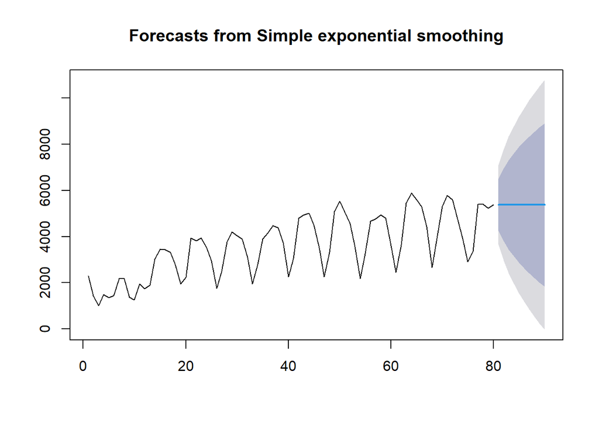

```r
ses.opt <- ses(train.ts, h = 10, alpha = NULL)
plot(ses.opt)
```

```r
ses.opt
```

```
##    Point Forecast    Lo 80    Hi 80      Lo 95     Hi 95
## 81       5370.986 4252.647 6489.325 3660.63417  7081.337
## 82       5370.986 3789.495 6952.477 2952.30427  7789.667
## 83       5370.986 3434.095 7307.876 2408.76737  8333.204
## 84       5370.986 3134.476 7607.496 1950.53909  8791.433
## 85       5370.986 2870.504 7871.467 1546.82925  9195.142
## 86       5370.986 2631.855 8110.117 1181.84615  9560.125
## 87       5370.986 2412.393 8329.579  846.20861  9895.763
## 88       5370.986 2208.123 8533.849  533.80415 10208.167
## 89       5370.986 2016.268 8725.704  240.38701 10501.585
## 90       5370.986 1834.806 8907.165  -37.13417 10779.106
```

```r
#Lamda Optimum Holt Winter
HWopt<- HoltWinters(train.ts, gamma = FALSE, beta = FALSE,alpha = NULL)
HWopt
```

```
## Holt-Winters exponential smoothing without trend and without seasonal component.
##
## Call:
## HoltWinters(x = train.ts, alpha = NULL, beta = FALSE, gamma = FALSE)
##
## Smoothing parameters:
##  alpha: 0.9999339
##  beta : FALSE
##  gamma: FALSE
##
## Coefficients:
##       [,1]
## a 5370.991
```

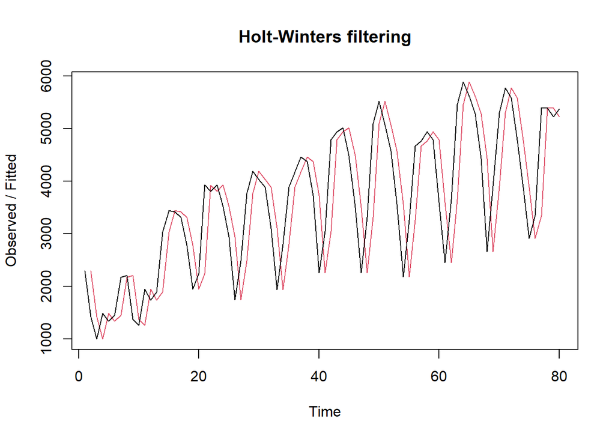

```r
plot(HWopt)
```

```r
ramalanopt<- forecast(HWopt, h=10)
ramalanopt
```

```
##    Point Forecast    Lo 80    Hi 80      Lo 95     Hi 95
## 81       5370.991 4256.789 6485.192 3666.96651  7075.015
## 82       5370.991 3795.324 6946.657 2961.21628  7780.765
## 83       5370.991 3441.222 7300.759 2419.66437  8322.317
## 84       5370.991 3142.698 7599.283 1963.11139  8778.870
## 85       5370.991 2879.692 7862.289 1560.87840  9181.103
## 86       5370.991 2641.916 8100.065 1197.23100  9544.750
## 87       5370.991 2423.258 8318.724  862.82208  9879.159
## 88       5370.991 2219.735 8522.246  551.56142 10190.420
## 89       5370.991 2028.583 8713.399  259.21871 10482.763
## 90       5370.991 1847.786 8894.195  -17.28613 10759.267
```

### Evaluasi dan Akurasi Data Latih dan Data Uji

```r
# Akurasi Data Uji pada alpha = 0.2
SSE_1<-ses1$SSE
MSE_1<-ses1$SSE/length(train.ts)
RMSE_1<-sqrt(MSE_1)
error_train_1 <- residuals(ses1)
MAPE_1 <- mean(abs(error_train_1 / train.ts) * 100)

akurasi_1 <- matrix(c(SSE_1,MSE_1,RMSE_1,MAPE_1))
row.names(akurasi_1)<- c("SSE", "MSE", "RMSE","MAPE")
colnames(akurasi_1) <- c("Akurasi lamda=0.2")
akurasi_1
```

```
##      Akurasi lamda=0.2
## SSE       7.761201e+07
## MSE       9.701501e+05
## RMSE      9.849620e+02
## MAPE      2.730286e+01
```

```r
# Akurasi Data Uji pada alpha = 0.7
SSE_2<-ses2$SSE
MSE_2<-ses2$SSE/length(train.ts)
RMSE_2<-sqrt(MSE_2)
error_train_2 <- residuals(ses2)
MAPE_2 <- mean(abs(error_train_2 / train.ts) * 100)

akurasi_2 <- matrix(c(SSE_2,MSE_2,RMSE_2,MAPE_2))
row.names(akurasi_2)<- c("SSE", "MSE", "RMSE","MAPE")
colnames(akurasi_2) <- c("Akurasi lamda=0.7")
akurasi_2
```

```
##      Akurasi lamda=0.7
## SSE       7.046503e+07
## MSE       8.808129e+05
## RMSE      9.385163e+02
## MAPE      2.414847e+01
```

Berdasarkan nilai SSE, MSE, RMSE, dan MAPE di antara kedua parameter, nilai parameter λ = 0,7 menghasilkan akurasi yang lebih baik dibanding λ = 0,2.

```r
# Akurasi Data Uji
n_test <- nrow(testing)
aktual <- as.numeric(testing$Page.Loads)

# error (ramalan - aktual), samakan panjang dan tipe numeric
e1   <- as.numeric(ramalan1$mean)[1:n_test] - as.numeric(testing$Page.Loads)
e2   <- as.numeric(ramalan2$mean)[1:n_test] - as.numeric(testing$Page.Loads)
eopt <- as.numeric(ramalanopt$mean)[1:n_test] - as.numeric(testing$Page.Loads)

MAPE_testing1 <- mean(abs(e1/aktual)*100, na.rm=TRUE)
MAPE_testing2 <- mean(abs(e2/aktual)*100, na.rm=TRUE)
MAPE_opt <- mean(abs(eopt/aktual)*100, na.rm = TRUE)

akurasitesting_MAPE <- matrix(c(MAPE_testing1, MAPE_testing2, MAPE_opt),
                              nrow=3,
                              dimnames=list(c("MAPE1","MAPE2","MAPEopt"),"Nilai"))
akurasitesting_MAPE
```

```
##            Nilai
## MAPE1   29.24223
## MAPE2   34.15689
## MAPEopt 34.78708
```

Pada data uji, hasil akurasi menunjukkan bahwa λ = 0,2 menghasilkan MAPE yang paling kecil dibandingkan dengan λ = 0,7. Namun, hasil MAPE yang lebih dari 20% mengindikasikan bahwa pemulusan SES belum cukup efektif untuk melakukan prediksi.

# Proses Pemulusan Winter

## Pembagian Data

Pembagian Data Latih dan Data Uji dengan bobot Data Latih 80% dan Data Uji 20%

```r
training<-df[1:80,2]
testing<-df[81:100,2]
training.ts<-ts(training, frequency = 7)
testing.ts<-ts(testing, frequency = 7)
```

Frekuensi = 7 dikarenakan pola pada data cenderung memiliki pattern / pola musiman pada rentang mingguan.

## Eksplorasi Data Hasil Pembagian

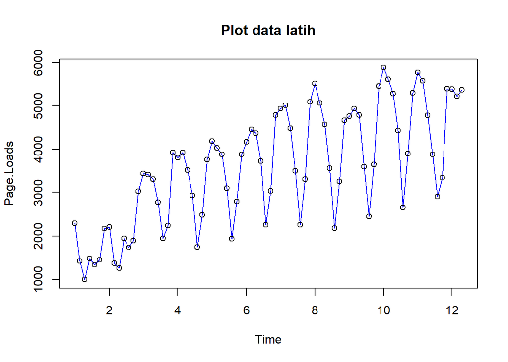

```r
# Eksplorasi Data Latih
plot(training.ts, col="blue",main="Plot data latih")
points(training.ts)
```

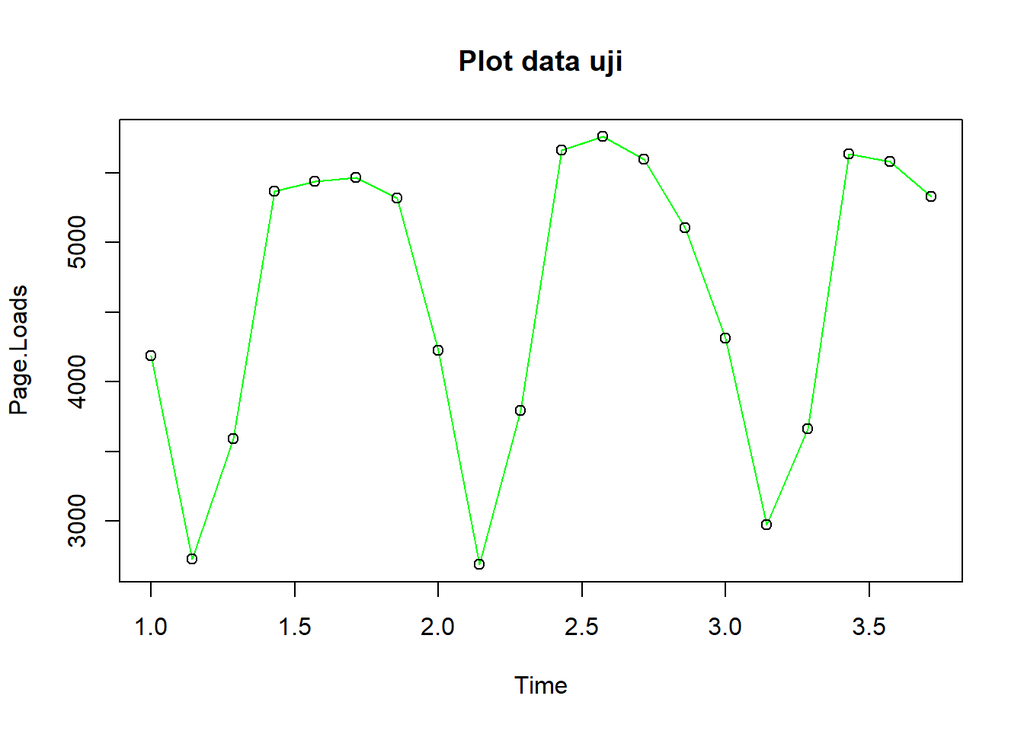

```r
# Eksplorasi Data Uji
plot(testing.ts, col="green",main="Plot data uji")
points(testing.ts)
```

## Winter Aditif

Perhitungan dengan model aditif dilakukan jika plot data asli menunjukkan fluktuasi musiman yang relatif stabil (konstan)

```r
winter1 <- HoltWinters(training.ts,alpha=0.2,beta=0.1,gamma=0.1,seasonal = "additive")
winter1$fitted
```

```
## Time Series:
## Start = c(2, 1)
## End = c(12, 3)
## Frequency = 7
##               xhat    level       trend       season
##  2.000000 2085.151 1480.801  46.6156463   557.734694
##  2.142857 1275.079 1551.986  49.0726190  -325.979592
##  2.285714 1168.169 1622.243  51.1910306  -505.265306
##  2.428571 1733.091 1692.800  53.1276535   -12.836735
##  2.571429 1637.642 1788.910  57.4258274  -208.693878
##  2.714286 1833.026 1867.207  59.5129928   -93.693878
##  2.857143 2588.822 1939.315  60.7724652   588.734694
##  3.000000 2726.142 2088.923  69.6560224   567.562585
##  3.142857 2068.878 2302.351  84.0331899  -317.505946
##  3.285714 2270.805 2657.208 111.1156308  -497.518814
##  3.428571 3114.398 2977.963 132.0795282     4.355961
##  3.571429 2968.869 3043.763 125.4515601  -200.345216
##  3.714286 2982.299 2965.841 105.1141779   -88.655988
##  3.857143 3638.132 2923.495  90.3682040   624.268923
##  4.000000 3793.074 3071.837  96.1655626   625.071255
##  4.142857 3058.715 3171.388  96.5040916  -209.176182
##  4.285714 3142.635 3442.349 113.9497818  -413.663225
##  4.428571 3731.772 3632.371 121.5570791   -22.155912
##  4.571429 3420.261 3596.174 105.7816291  -281.694745
##  4.714286 3292.860 3368.103  72.3964131  -147.639883
##  4.857143 3983.945 3280.128  56.3592149   647.458357
##  5.000000 3971.324 3292.898  52.0003072   626.425371
##  5.142857 3306.494 3389.434  56.4538346  -139.393422
##  5.285714 3280.038 3592.189  71.0839558  -383.234036
##  5.428571 3783.510 3785.465  83.3031858   -85.257712
##  5.571429 3388.883 3734.266  69.8529796  -415.235608
##  5.714286 3344.749 3515.542  40.9953131  -211.788676
##  5.857143 4108.151 3447.988  30.1403349   630.022727
##  6.000000 4104.955 3434.898  25.8173176   644.239481
##  6.142857 3420.410 3474.124  27.1582223   -80.872937
##  6.285714 3423.674 3710.001  48.0300300  -334.357115
##  6.428571 3876.734 3948.696  67.0965591  -139.058536
##  6.571429 3520.821 3987.246  64.2418797  -530.666275
##  6.714286 3583.580 3799.723  39.0654533  -255.208589
##  6.857143 4373.197 3732.073  28.3938494   612.730657
```

[output cut: 23 more lines]

```
## 10.285714 4564.080 4651.448  48.7436549  -136.111777
## 10.428571 4586.007 4845.176  63.2420482  -322.411213
## 10.571429 3985.697 4878.017  60.2019105  -952.522056
## 10.714286 4317.037 4674.079  33.7879791  -390.830777
## 10.857143 5380.244 4625.860  25.5872488   728.796314
## 11.000000 5468.920 4636.999  24.1423778   807.778918
## 11.142857 5025.994 4721.957  30.2239813   273.812625
## 11.285714 4827.268 4863.982  41.4041104   -78.118204
## 11.428571 4602.480 4896.533  40.5187480  -334.571763
## 11.571429 3763.307 4795.156  26.3291543 -1058.177782
## 11.714286 4237.993 4652.223   9.4030166  -423.633698
## 11.857143 5199.348 4484.628  -8.2968355   723.016830
## 12.000000 5344.283 4516.461  -4.2837911   832.105332
## 12.142857 4837.585 4522.321  -3.2694497   318.533141
## 12.285714 4520.234 4597.335   4.5588562   -81.659653
```

```r
xhat1 <- winter1$fitted[,2]

winter1.opt<- HoltWinters(training.ts, alpha= NULL,  beta = NULL, gamma = NULL, seasonal = "additive")
winter1.opt
```

```
## Holt-Winters exponential smoothing with trend and additive seasonal component.
##
## Call:
## HoltWinters(x = training.ts, alpha = NULL, beta = NULL, gamma = NULL,     seasonal = "additive")
##
## Smoothing parameters:
##  alpha: 0.3152348
##  beta : 0
##  gamma: 0.9836116
##
## Coefficients:
##           [,1]
## a   4705.33771
## b     46.61565
## s1  -570.52466
## s2 -1740.24782
## s3 -1161.44217
## s4   793.82993
## s5   882.08602
## s6   755.94628
## s7   659.16426
```

```r
xhat1.opt <- winter1.opt$fitted[,2]
```

### Peramalan

```r
forecast1 <- predict(winter1, n.ahead = 20)
forecast1.opt <- predict(winter1.opt, n.ahead = 20)
```

### Plot Deret Waktu

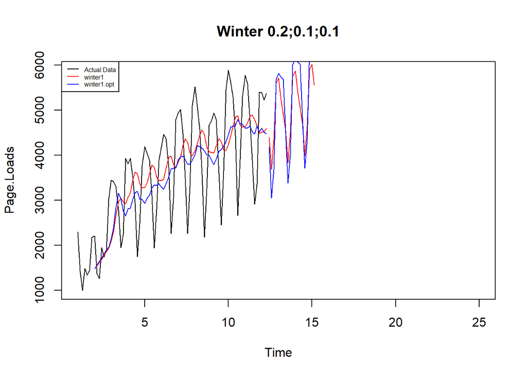

```r
plot(training.ts,main="Winter 0.2;0.1;0.1",type="l",col="black",
     xlim=c(1,25),pch=12)
lines(xhat1,type="l",col="red")
lines(xhat1.opt,type="l",col="blue")
lines(forecast1,type="l",col="red")
lines(forecast1.opt,type="l",col="blue")
legend("topleft",c("Actual Data",expression(paste(winter1)),
                   expression(paste(winter1.opt))),cex=0.5,
       col=c("black","red","blue"),lty=1)
```

### Evaluasi dan Akurasi Data Latih dan Data Uji

```r
#Akurasi Data Latih
SSE1<-winter1$SSE
MSE1<-winter1$SSE/length(training.ts)
RMSE1<-sqrt(MSE1)
error_train1 <- residuals(winter1)
MAPE_winter1 <- mean(abs(error_train1 / training.ts) * 100)
akurasi1 <- matrix(c(SSE1,MSE1,RMSE1,MAPE_winter1))
row.names(akurasi1)<- c("SSE", "MSE", "RMSE","MAPE")
colnames(akurasi1) <- c("Akurasi")
akurasi1
```

```
##           Akurasi
## SSE  3.796873e+07
## MSE  4.746091e+05
## RMSE 6.889188e+02
## MAPE 1.870315e+01
```

```r
SSE1.opt<-winter1.opt$SSE
MSE1.opt<-winter1.opt$SSE/length(training.ts)
RMSE1.opt<-sqrt(MSE1.opt)
error_test1 <- residuals(winter1.opt)
MAPE_winter2 <- mean(abs(error_test1 / testing.ts) * 100)
akurasi1.opt <- matrix(c(SSE1.opt,MSE1.opt,RMSE1.opt, MAPE_winter2))
row.names(akurasi1.opt)<- c("SSE1.opt", "MSE1.opt", "RMSE1.opt","MAPE.opt")
colnames(akurasi1.opt) <- c("Akurasi")
akurasi1.opt
```

```
##                Akurasi
## SSE1.opt  1.081404e+07
## MSE1.opt  1.351755e+05
## RMSE1.opt 3.676622e+02
## MAPE.opt  1.081145e+01
```

Perhitungan akurasi menggunakan data latih menghasilkan nilai MAPE kurang dari 20%. Hasil ini menandakan akurasi yang cukup baik.

```r
#Akurasi Data Uji
selisih1<-as.numeric(forecast1) - as.numeric(testing.ts)
SSEtesting1<-sum(selisih1^2)
MSEtesting1<-SSEtesting1/length(testing.ts)
MAPE_wintertest1<-mean(abs(selisih1/testing.ts)*100)

selisih1.opt<-as.numeric(forecast1.opt)-as.numeric(testing.ts)
SSEtesting1.opt<-sum(selisih1.opt^2)
MSEtesting1.opt<-SSEtesting1.opt/length(testing.ts)
MAPE_wintertest1.opt<-mean(abs(selisih1.opt/testing.ts)*100)
```

```r
akurasi_testing <- data.frame(
  Model = c("Model1", "Model Optimum"),
  SSE   = c(SSEtesting1, SSEtesting1.opt),
  MSE   = c(MSEtesting1, MSEtesting1.opt),
  MAPE  = c(MAPE_wintertest1, MAPE_wintertest1.opt)
)

akurasi_testing
```

```
##           Model     SSE      MSE     MAPE
## 1        Model1 6348652 317432.6 12.32558
## 2 Model Optimum 6222682 311134.1 11.07245
```

## Winter Multiplikatif

Model multiplikatif digunakan cocok digunakan jika plot data asli menunjukkan fluktuasi musiman yang bervariasi.

```r
winter2 <- HoltWinters(training.ts,alpha=0.2,beta=0.1,gamma=0.3,seasonal = "multiplicative")
winter2$fitted
```

```
## Time Series:
## Start = c(2, 1)
## End = c(12, 3)
## Frequency = 7
##               xhat    level       trend    season
##  2.000000 2036.070 1480.801  46.6156463 1.3330152
##  2.142857 1292.407 1553.212  49.1952168 0.8065407
##  2.285714 1194.564 1624.376  51.3920825 0.7128453
##  2.428571 1724.221 1695.530  53.3682858 0.9858893
##  2.571429 1595.616 1794.295  57.9079329 0.8614694
##  2.714286 1820.461 1886.188  61.3063972 0.9347708
##  2.857143 2767.231 1963.656  62.9226098 1.3654692
##  3.000000 2899.065 2065.506  66.8153237 1.3595816
##  3.142857 1874.885 2212.631  74.8462522 0.8196302
##  3.285714 2007.879 2665.236 112.6221854 0.7228155
##  3.428571 3341.586 3140.640 148.9003478 1.0158215
##  3.571429 2919.686 3179.563 137.9026347 0.8800954
##  3.714286 3033.529 3097.561 115.9121447 0.9440033
##  3.857143 4392.384 3046.412  99.2060771 1.3963500
##  4.000000 4499.944 3079.104  92.5546723 1.4187982
##  4.142857 3027.896 3074.402  82.8289163 0.9590353
##  4.285714 2837.098 3345.566 101.6625161 0.8230081
##  4.428571 3633.928 3613.911 118.3306979 0.9736583
##  4.571429 2974.476 3590.317 104.1382902 0.8051188
##  4.714286 3055.084 3390.531  73.7458647 0.8818820
##  4.857143 4620.854 3336.350  60.9531361 1.3601537
##  5.000000 4531.577 3271.603  48.3831673 1.3649384
##  5.142857 3392.901 3270.523  43.4367562 1.0238211
##  5.285714 3036.496 3439.977  56.0385388 0.8685590
##  5.428571 3495.174 3692.779  75.7149062 0.9274722
##  5.571429 2696.644 3685.651  67.4305913 0.7185146
##  5.714286 3020.851 3544.138  46.5362637 0.8413047
##  5.857143 4644.821 3538.648  41.3335951 1.2974428
##  6.000000 4682.089 3463.935  29.7288995 1.3401661
##  6.142857 3676.402 3417.540  22.1165701 1.0688283
##  6.285714 3348.814 3587.033  36.8541584 0.9240947
##  6.428571 3524.561 3846.415  59.1069779 0.9024558
##  6.571429 2681.205 3951.937  63.7485127 0.6676829
##  6.714286 3257.339 3890.116  51.1915099 0.8264616
##  6.857143 4903.062 3891.132  46.1739907 1.2452833
```

[output cut: 23 more lines]

```
## 10.285714 4826.724 4520.482  36.5245693 1.0591876
## 10.428571 4074.127 4644.295  45.2534458 0.8687675
## 10.571429 2828.624 4772.395  53.5381257 0.5861300
## 10.714286 3938.442 4770.101  47.9549186 0.8174338
## 10.857143 5932.317 4810.363  47.1856316 1.2212574
## 11.000000 6147.408 4755.307  36.9614570 1.2827762
## 11.142857 5711.324 4733.894  31.1239914 1.1985945
## 11.285714 5169.475 4743.939  29.0161181 1.0830763
## 11.428571 4189.080 4701.589  21.8795099 0.8868652
## 11.571429 2699.880 4656.699  15.2025090 0.5778975
## 11.714286 3891.480 4747.043  22.7166416 0.8158651
## 11.857143 5529.085 4637.757   9.5164172 1.1897481
## 12.000000 5855.059 4625.574   7.3464653 1.2637944
## 12.142857 5436.664 4560.114   0.0658719 1.1922037
## 12.285714 4808.381 4525.343  -3.4178202 1.0633481
```

```r
xhat2 <- winter2$fitted[,2]

winter2.opt<- HoltWinters(training.ts, alpha= NULL,  beta = NULL, gamma = NULL, seasonal = "multiplicative")
winter2.opt$fitted
```

```
## Time Series:
## Start = c(2, 1)
## End = c(12, 3)
## Frequency = 7
##               xhat    level    trend    season
##  2.000000 2036.070 1480.801 46.61565 1.3330152
##  2.142857 1291.969 1555.249 46.61565 0.8065407
##  2.285714 1192.092 1625.685 46.61565 0.7128453
##  2.428571 1716.420 1694.371 46.61565 0.9858893
##  2.571429 1583.631 1791.674 46.61565 0.8614694
##  2.714286 1799.037 1877.960 46.61565 0.9347708
##  2.857143 2722.165 1946.959 46.61565 1.3654692
##  3.000000 2948.949 2042.697 46.61565 1.4114445
##  3.142857 1869.816 2165.152 46.61565 0.8453942
##  3.285714 1973.535 2608.223 46.61565 0.7433731
##  3.428571 3331.928 3045.406 46.61565 1.0775889
##  3.571429 2790.348 2982.097 46.61565 0.9212982
##  3.714286 2792.896 2832.352 46.61565 0.9701033
##  3.857143 4131.060 2757.094 46.61565 1.4734263
##  4.000000 4439.562 2773.971 46.61565 1.5739856
##  4.142857 3525.813 2734.275 46.61565 1.2678719
##  4.285714 3061.022 2849.853 46.61565 1.0568117
##  4.428571 2876.420 2990.799 46.61565 0.9469962
##  4.571429 2204.482 3052.586 46.61565 0.7113064
##  4.714286 2494.191 2961.629 46.61565 0.8291185
##  4.857143 4341.281 3007.414 46.61565 1.4214929
##  5.000000 4250.686 2966.699 46.61565 1.4106345
##  5.142857 4176.383 3004.643 46.61565 1.3687411
##  5.285714 3587.910 3029.442 46.61565 1.1663989
##  5.428571 3059.448 3132.131 46.61565 0.9624700
##  5.571429 1950.811 3190.305 46.61565 0.6026751
##  5.714286 2718.542 3235.198 46.61565 0.8283657
##  5.857143 4301.351 3303.554 46.61565 1.2839202
##  6.000000 4650.027 3281.370 46.61565 1.3972499
##  6.142857 4410.936 3254.160 46.61565 1.3363335
##  6.285714 4144.783 3309.344 46.61565 1.2350515
##  6.428571 3353.400 3396.533 46.61565 0.9739341
##  6.571429 2150.245 3527.476 46.61565 0.6016200
##  6.714286 3098.087 3614.176 46.61565 0.8462889
##  6.857143 4417.235 3648.530 46.61565 1.1954156
```

[output cut: 23 more lines]

```
## 10.285714 5408.105 4490.598 46.61565 1.1919439
## 10.428571 4072.275 4515.651 46.61565 0.8925991
## 10.571429 2759.886 4649.715 46.61565 0.5876686
## 10.714286 4035.588 4661.489 46.61565 0.8571577
## 10.857143 5915.667 4675.733 46.61565 1.2526960
## 11.000000 6122.092 4617.672 46.61565 1.3125461
## 11.142857 5825.933 4606.895 46.61565 1.2519436
## 11.285714 5465.613 4611.982 46.61565 1.1732313
## 11.428571 4340.564 4533.047 46.61565 0.9477912
## 11.571429 2593.497 4477.763 46.61565 0.5732274
## 11.714286 3930.888 4646.160 46.61565 0.8376468
## 11.857143 5321.947 4543.903 46.61565 1.1593345
## 12.000000 5855.450 4605.047 46.61565 1.2587864
## 12.142857 5611.956 4572.729 46.61565 1.2148812
## 12.285714 4903.230 4551.324 46.61565 1.0663972
```

```r
xhat2.opt <- winter2.opt$fitted[,2]
```

### Peramalan

```r
forecast2 <- predict(winter2, n.ahead = 20)
forecast2.opt <- predict(winter2.opt, n.ahead = 20)
```

### Plot Deret Waktu

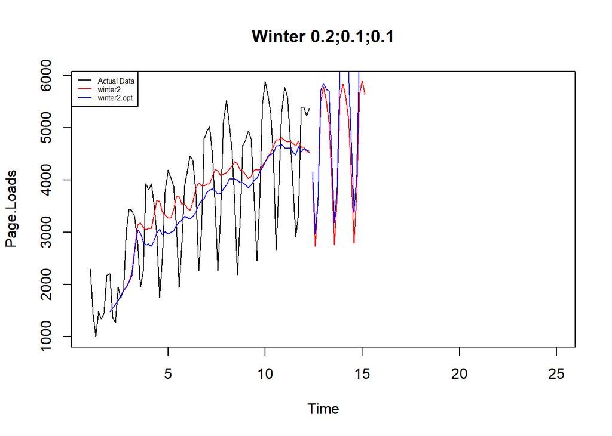

```r
plot(training.ts,main="Winter 0.2;0.1;0.1",type="l",col="black",
     xlim=c(1,25),pch=12)
lines(xhat2,type="l",col="red")
lines(xhat2.opt,type="l",col="blue")
lines(forecast2,type="l",col="red")
lines(forecast2.opt,type="l",col="blue")
legend("topleft",c("Actual Data",expression(paste(winter2)),
                   expression(paste(winter2.opt))),cex=0.5,
       col=c("black","red","blue"),lty=1)
```

### Evaluasi dan Akurasi Data Latih dan Data Uji

```r
# Akurasi Data Latih
SSE2<-winter2$SSE
MSE2<-winter2$SSE/length(training.ts)
RMSE2<-sqrt(MSE2)
error_train3 <- residuals(winter2)
MAPE_winter3 <- mean(abs(error_train3 / training.ts) * 100)
akurasi2 <- matrix(c(SSE2,MSE2,RMSE2,MAPE_winter3))
row.names(akurasi2)<- c("SSE2", "MSE2", "RMSE2","MAPE")
colnames(akurasi2) <- c("Akurasi lamda=0.2")
akurasi2
```

```
##       Akurasi lamda=0.2
## SSE2       2.119431e+07
## MSE2       2.649288e+05
## RMSE2      5.147124e+02
## MAPE       1.319318e+01
```

```r
SSE2.opt<-winter2.opt$SSE
MSE2.opt<-winter2.opt$SSE/length(training.ts)
RMSE2.opt<-sqrt(MSE2.opt)
error_test3 <- residuals(winter2.opt)
MAPE_winter4 <- mean(abs(error_test3 / testing.ts) * 100)
akurasi2.opt <- matrix(c(SSE2.opt,MSE2.opt,RMSE2.opt,MAPE_winter4))
row.names(akurasi2.opt)<- c("SSE2.opt", "MSE2.opt", "RMSE2.opt","MAPE")
colnames(akurasi2.opt) <- c("Akurasi")
akurasi2.opt
```

```
##                Akurasi
## SSE2.opt  1.284923e+07
## MSE2.opt  1.606154e+05
## RMSE2.opt 4.007685e+02
## MAPE      1.227190e+01
```

Perhitungan akurasi menggunakan data latih menghasilkan nilai MAPE kurang dari 20%. Hasil tersebut menunjukkan hasil pemulusan yang sangat baik.

```r
# Akurasi Data Uji
selisih2<-as.numeric(forecast2)-as.numeric(testing.ts)
SSEtesting2<-sum(selisih2^2)
MSEtesting2<-SSEtesting2/length(testing.ts)
MAPE_wintertest2<-mean(abs(selisih2/testing.ts)*100, na.rm = TRUE)

selisih2.opt<-as.numeric(forecast2.opt)-as.numeric(testing.ts)
SSEtesting2.opt<-sum(selisih2.opt^2)
MSEtesting2.opt<-SSEtesting2.opt/length(testing.ts)
MAPE_Wintertest2.opt<-mean(abs(selisih2.opt/testing.ts)*100, na.rm = TRUE)
```

```r
akurasi_testing2 <- data.frame(
  Model = c("Model2", "Model2 Optimal"),
  SSE   = c(SSEtesting2, SSEtesting2.opt),
  MSE   = c(MSEtesting2, MSEtesting2.opt),
  MAPE  = c(MAPE_wintertest2, MAPE_Wintertest2.opt)
)

akurasi_testing2
```

```
##            Model       SSE       MSE     MAPE
## 1         Model2  534116.9  26705.84 2.853342
## 2 Model2 Optimal 6224328.5 311216.43 9.898705
```

Perhitungan akurasi menggunakan data uji menghasilkan nilai MAPE kurang dari 10%. Hasil tersebut menunjukkan nilai akurasi yang sangat baik, menandakan bahwa pemulusan Winter Multiplikatif memberikan hasil pemulusan yang terbaik.

# Kesimpulan

Metode pemulusan Winter Multiplikatif cocok diterapkan untuk memberikan nilai prediksi yang paling baik dibandingkan dengan metode Winter Aditif, Single Exponential Smoothing, Single Moving Average dan Double Moving Average. Hal ini sejalan dengan visualisasi data deret waktu yang cenderung memiliki pola musiman dan tren yang positif.